# DS_FinalProject

peteryu

2018/1/8

## Occupancy detection using UCI ML repository dataset.

This is the final project from Data Science class @ NCCU CS.

Our target is to find out if the office is availabel for use from this dataset.

### Data loading

First, load dataset from ‘./occupancy_data’.

```r
train <- read.csv('./occupancy_data/train.csv', stringsAsFactors = F)
test1 <- read.csv('./occupancy_data/test1.csv', stringsAsFactors = F)
test2 <- read.csv('./occupancy_data/test2.csv', stringsAsFactors = F)
```

In training data, there are total 8144 rows.

In testing data, there are 12416 rows.

Here only shows a few rows from those data.

There are seven attributes collecting from sensor inside the office.

No missing data is this dataset.

```r
head(train)
```

```
##             Date Temperature Humidity Light    CO2 HumidityRatio Occupancy
## 1 2015/2/4 17:51       23.18  27.2720 426.0 721.25   0.004792988         1
## 2 2015/2/4 17:51       23.15  27.2675 429.5 714.00   0.004783441         1
## 3 2015/2/4 17:53       23.15  27.2450 426.0 713.50   0.004779464         1
## 4 2015/2/4 17:54       23.15  27.2000 426.0 708.25   0.004771509         1
## 5 2015/2/4 17:55       23.10  27.2000 426.0 704.50   0.004756993         1
## 6 2015/2/4 17:55       23.10  27.2000 419.0 701.00   0.004756993         1
```

```r
head(test1)
```

```
##             Date Temperature Humidity    Light      CO2 HumidityRatio
## 1 2015/2/2 14:19     23.7000   26.272 585.2000 749.2000   0.004764163
## 2 2015/2/2 14:19     23.7180   26.290 578.4000 760.4000   0.004772661
## 3 2015/2/2 14:21     23.7300   26.230 572.6667 769.6667   0.004765153
## 4 2015/2/2 14:22     23.7225   26.125 493.7500 774.7500   0.004743773
## 5 2015/2/2 14:23     23.7540   26.200 488.6000 779.0000   0.004766594
## 6 2015/2/2 14:23     23.7600   26.260 568.6667 790.0000   0.004779332
##   Occupancy
## 1         1
## 2         1
## 3         1
## 4         1
## 5         1
## 6         1
```

### Data preprocessing

Now, we need to do some data preprocessing.

Combine training and testing data. Since ‘Date’ is time serial, we want some categorical attributes, so convert it into Weekdays and Time.

```r
full <- bind_rows(train, test1, test2)
full$Weekdays <- sapply(full$Date, function(x) if(weekdays(as.Date(strsplit(x, " ")[[1]][1])) == '週六' || weekdays(as.Date(strsplit(x, " ")[[1]][1])) == '週日') 'weekend' else 'weekday')
full$Time <- sapply(full$Date, function(x) if(strsplit(x, " ")[[1]][2] < '12:00' && strsplit(x, " ")[[1]][2] > '00:00') 'morning' else if(strsplit(x, " ")[[1]][2] > '18:00') 'evening' else 'afternoon')

head(full)
```

```
##             Date Temperature Humidity Light    CO2 HumidityRatio Occupancy
## 1 2015/2/4 17:51       23.18  27.2720 426.0 721.25   0.004792988         1
## 2 2015/2/4 17:51       23.15  27.2675 429.5 714.00   0.004783441         1
## 3 2015/2/4 17:53       23.15  27.2450 426.0 713.50   0.004779464         1
## 4 2015/2/4 17:54       23.15  27.2000 426.0 708.25   0.004771509         1
## 5 2015/2/4 17:55       23.10  27.2000 426.0 704.50   0.004756993         1
## 6 2015/2/4 17:55       23.10  27.2000 419.0 701.00   0.004756993         1
##   Weekdays      Time
## 1  weekday afternoon
## 2  weekday afternoon
## 3  weekday afternoon
## 4  weekday afternoon
## 5  weekday afternoon
## 6  weekday afternoon
```

Preprocessing is done, split dataset into training and testing data.

We don’t need ‘Date’ attribute for model construction, so here we use dataset from column index 2.

```r
train <- full[1:8144, 2:9]
test <- full[8145:20560, 2:9]
```

For further model comparsion, we generate two list with all prediction of zero(vacant), and one(occupy).

```
## [1] 0 0 0 0 0 0
```

```
## [1] 1 1 1 1 1 1
```

Summary about training and testing data.

```r
train$Occupancy <- as.factor(train$Occupancy)
test$Occupancy  <- as.factor(test$Occupancy)

summary(train)
```

```
##   Temperature       Humidity         Light             CO2
##  Min.   :19.00   Min.   :16.75   Min.   :   0.0   Min.   : 412.8
##  1st Qu.:19.70   1st Qu.:20.20   1st Qu.:   0.0   1st Qu.: 439.0
##  Median :20.39   Median :26.22   Median :   0.0   Median : 453.5
##  Mean   :20.62   Mean   :25.73   Mean   : 119.6   Mean   : 606.6
##  3rd Qu.:21.39   3rd Qu.:30.53   3rd Qu.: 256.8   3rd Qu.: 639.0
##  Max.   :23.70   Max.   :39.12   Max.   :1546.3   Max.   :2028.5
##  HumidityRatio      Occupancy   Weekdays             Time
##  Min.   :0.002674   0:6414    Length:8144        Length:8144
##  1st Qu.:0.003079   1:1730    Class :character   Class :character
##  Median :0.003801             Mode  :character   Mode  :character
##  Mean   :0.003863
##  3rd Qu.:0.004352
##  Max.   :0.006476
```

```r
summary(test)
```

```
##   Temperature       Humidity         Light             CO2
##  Min.   :19.50   Min.   :21.86   Min.   :   0.0   Min.   : 427.5
##  1st Qu.:20.39   1st Qu.:25.39   1st Qu.:   0.0   1st Qu.: 527.5
##  Median :20.79   Median :28.60   Median :   0.0   Median : 631.9
##  Mean   :21.09   Mean   :28.92   Mean   : 138.1   Mean   : 745.6
##  3rd Qu.:21.68   3rd Qu.:31.79   3rd Qu.: 390.9   3rd Qu.: 857.0
##  Max.   :24.41   Max.   :39.50   Max.   :1697.2   Max.   :2076.5
##  HumidityRatio      Occupancy   Weekdays             Time
##  Min.   :0.003275   0:9396    Length:12416       Length:12416
##  1st Qu.:0.003988   1:3020    Class :character   Class :character
##  Median :0.004511             Mode  :character   Mode  :character
##  Mean   :0.004468
##  3rd Qu.:0.004942
##  Max.   :0.005769
```

Plotting the correlation about attribute of training data.

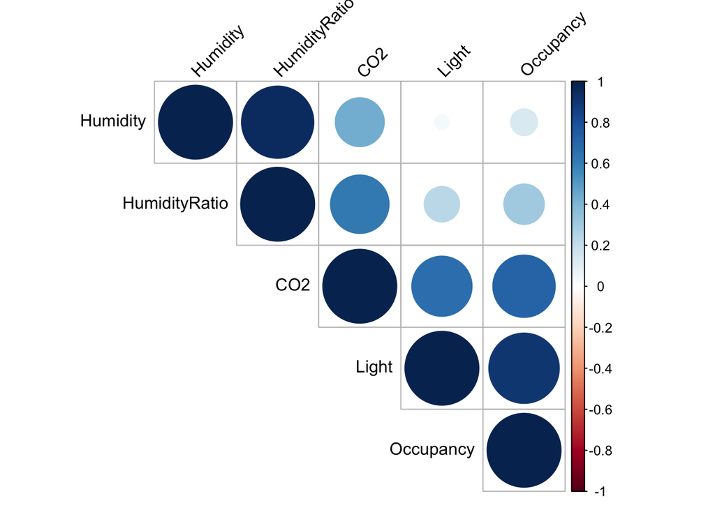

### Model Construction

Constructing our supervised learning model using random forest classifcation algorithm.

Underneath shows each attribute importance during decision tree classifier constructing.

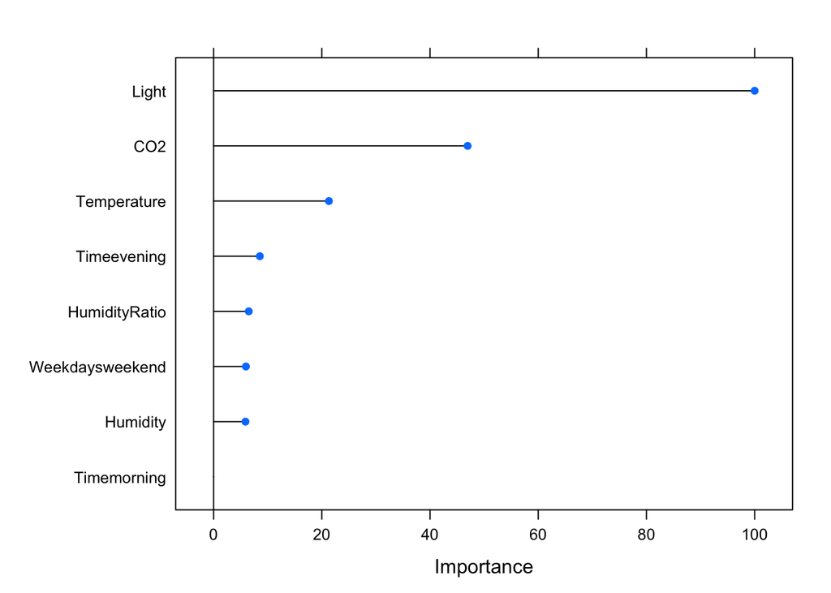

```r
set.seed(1234)
model_all <- train(Occupancy~.,method="rf",data=train)
plot(varImp(model_all,scale=TRUE))
```

Finally, the accuracy of this model compare to null model.

```
##           Model Accuracy
## 1 Random Forest 97.61598
## 2  null model-0 75.67655
## 3  null model-1 24.32345
```

The confusion matrix.

```
## Confusion Matrix and Statistics
##
##           Reference
## Prediction    0    1
##          0 9161  235
##          1   62 2958
##
##                Accuracy : 0.9761
##                  95% CI : (0.9732, 0.9787)
##     No Information Rate : 0.7428
##     P-Value [Acc > NIR] : < 2.2e-16
##
##                   Kappa : 0.9363
##  Mcnemar's Test P-Value : < 2.2e-16
##
##             Sensitivity : 0.9933
##             Specificity : 0.9264
##          Pos Pred Value : 0.9750
##          Neg Pred Value : 0.9795
##              Prevalence : 0.7428
##          Detection Rate : 0.7378
##    Detection Prevalence : 0.7568
##       Balanced Accuracy : 0.9598
##
##        'Positive' Class : 0
##
```